# final

TanQingyue

2020/6/10

### 1.前言

为有效度量自疫情发生以来我国股票市场上表现出的的不确定性和风险性，本文运用GARCH族模型拟合了股票指数收益率的波动性方程并实证研究了全球有代表性的美国标准普尔指数、香港恒生指数、日本日经指数和我国的沪深300指数。结果表明四个指数股票收益率均有聚集性、持续性，股票市场存在着冲击的非对称性。具体而言，美国、日本、中国香港股票市场对利坏消息敏感，而对利好消息保持谨慎。而沪深300指数代表的我国股市对利好利坏消息均敏感，体现出我国股票市场抗风险能力的薄弱性。此外，本文尝试使用SGARCH模型对股票收益率序列进行滚动预测，同时文章首创性的基于Var曲线提出了股市危机预警信号。研究表明在疫情爆发初始股市就已经发出了危机预警信号。

### 2.GARCH模型介绍

传统的波动性预测可以运用到期权定价，风险管理和以波动性为基础的交易策略。近年来GARCH模型族被广泛的运用在模拟预测金融资产的波动性上。标准GARCH模型于1986年被Bollerslev提出，之后为了规范条件方差，更多复杂的GRACH模型应运而生。

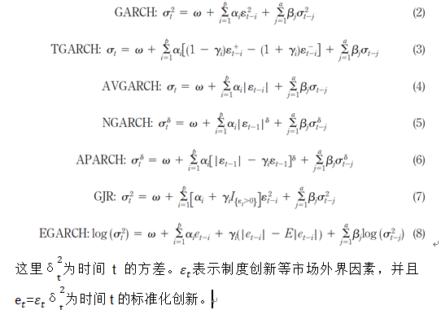

### 3.股票指数介绍

（一）标准普尔指数由美国最大的证券研究机构标准普尔公司编制的用以反映美国股市行情变动的股票价格指数。计算方法采用加权算术平均法，能比道.琼斯指数更精确的反映股票市场的变化，因此从研究角度讲，SP500指数更具有参考价值。

（二）日经股票价格指数由日本经济新闻社从1950年9月开始编制并公布，用以反映日本股票市场价格变动。日经指数分为两类：一是日经225指数，另一类是日经500指数。

（三）香港恒生指数由香港恒生银行于1969年11月24日开始发表，以在香港上市的33家有代表性且经济实力雄厚的大公司股票作为成分股，能够很好的代表香港股市现状。

（四）沪深300指数是由沪深证券交易所于2005年4月8日联合发布的，沪深300指数可以作为我国股票市场投资业绩的评价标准，为指数化投资和指数衍生产品创新提供基础条件。

### 4建模分析

接下来我们以沪深300指数为例，对股票数据进行GARCH建模分析。

### 4.1波动率分析

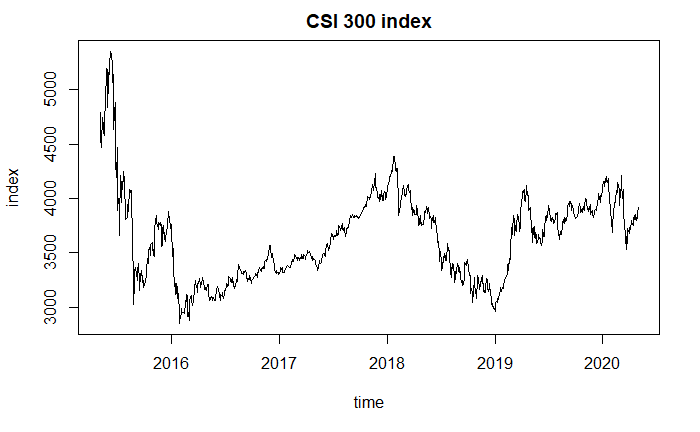

波动图表明，自2020年初新冠肺炎疫情爆发开始，我国沪深300指数收益率就表现出了一定程度的波动。

### 4.2正态性检验

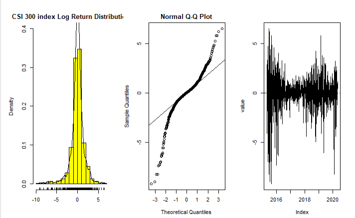

上图为数据分布函数，QQ图，对数收益率序列折现图。由数据分布图、QQ图可以看出金融时间序列确实表现出尖峰厚尾性，相对于标准正态分布，峰度更高，两段的尾部更厚，也就是极值更多。由收益率波动序列可以看出我国股票指数收益率序列在样本区间内均表现出一定的波动性和聚集性，其中2015-2016年、2020年初波动幅度尤为明显。

### 4.3平稳性检验

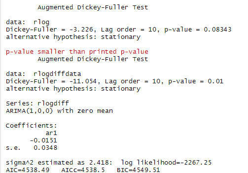

### 4.5模型拟合

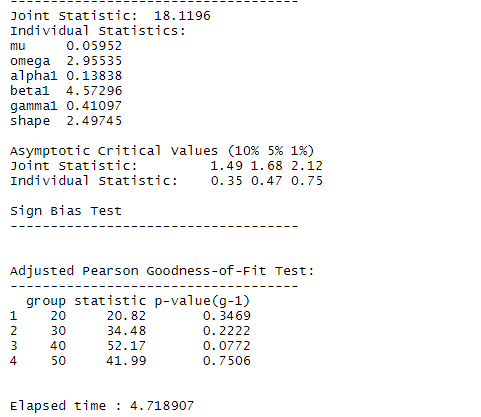

### 5.实证分析

### 5.1市场冲击分析

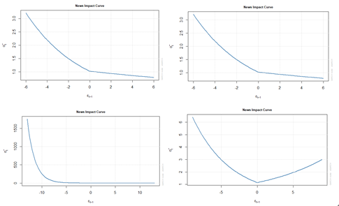

信息冲击小于零表示为利坏消息或负冲击，信息冲击大于零表示为利好消息或正冲击，由上图可以看出美国、日本、中国香港股票市场对利坏消息敏感，而对利好消息保持谨慎。而沪深300指数代表的我国股市对利好利坏消息均敏感，体现出我国股票市场抗风险能力的薄弱性

### 5.2基于VAR曲线的收益风险预警

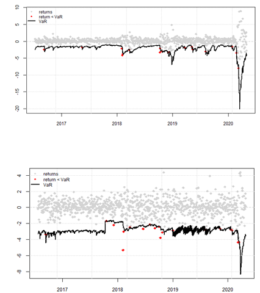